# Reproducible Research: Peer Assessment 1

## Loading and preprocessing the data

```r
setwd("~/Coursera/specdata")
data <- read.csv("activity.csv")
```

## Exclude rows where the number of steps records are na or missing

```r
sanitizedData <- data[complete.cases(data), ]
```

# Compute the Total Number of Steps Per Day

```r
aggregatedSum <- aggregate(sanitizedData$steps, by = list(sanitizedData$date),
    sum)
```

# Histogram of Total Number of Steps per day?

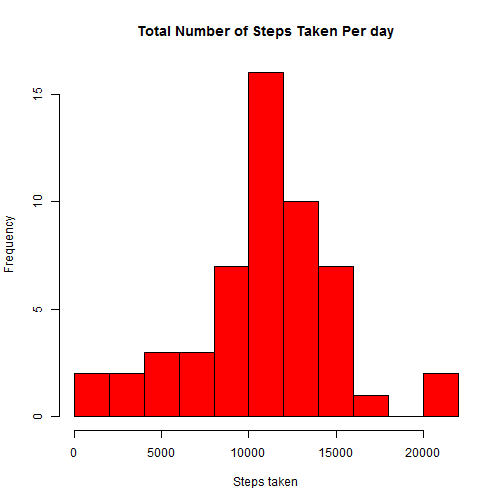

```r
h <- hist(aggregatedSum$x, breaks = 10, col = "red", xlab = "Steps taken", main = "Total Number of Steps Taken Per day")
```

# What is mean total number of steps taken per day?

```r
mean(aggregatedSum$x)
```

```
## [1] 10766
```

# What is median of total number of steps taken per day?

```r
median(aggregatedSum$x)
```

```
## [1] 10765
```

# Compute the Average Number of Steps Per Day By Date

```r
averagedDataByDate <- aggregate(sanitizedData$steps, by = list(sanitizedData$date),
    mean)
averagedDataByDate
```

```
##       Group.1       x
## 1  2012-10-02  0.4375
## 2  2012-10-03 39.4167
## 3  2012-10-04 42.0694
## 4  2012-10-05 46.1597
## 5  2012-10-06 53.5417
## 6  2012-10-07 38.2465
## 7  2012-10-09 44.4826
## 8  2012-10-10 34.3750
## 9  2012-10-11 35.7778
## 10 2012-10-12 60.3542
## 11 2012-10-13 43.1458
## 12 2012-10-14 52.4236
## 13 2012-10-15 35.2049
## 14 2012-10-16 52.3750
```

[output cut: 39 more lines]

# Compute the Average Number of Steps Per Day By Interval

```r
averagedDataByInterval <- aggregate(sanitizedData$steps, by = list(sanitizedData$interval),
    mean)
averagedDataByInterval
```

```
##     Group.1         x
## 1         0   1.71698
## 2         5   0.33962
## 3        10   0.13208
## 4        15   0.15094
## 5        20   0.07547
## 6        25   2.09434
## 7        30   0.52830
## 8        35   0.86792
## 9        40   0.00000
## 10       45   1.47170
## 11       50   0.30189
## 12       55   0.13208
## 13      100   0.32075
## 14      105   0.67925
```

[output cut: 274 more lines]

## What is the average daily activity pattern?

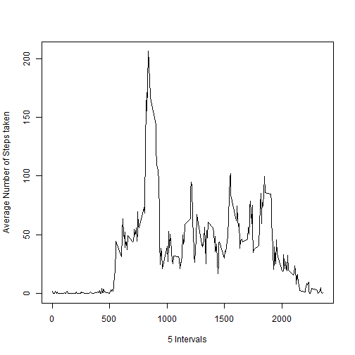

```r
plot(averagedDataByInterval$Group.1, averagedDataByInterval$x, type = "l", xlab = "5 Intervals",
    ylab = "Average Number of Steps taken")
```

## 5 Minute Interval on Average across all days which contains maximum number of steps

```r
IntervalWithMaxSteps <- averagedDataByInterval[averagedDataByInterval$x == max(averagedDataByInterval$x),
    ]

IntervalWithMaxSteps$Group.1
```

```
## [1] 835
```

## Total Number of Rows With Missing values In the data Set?

```r
nrow(data) - nrow(sanitizedData)
```

```
## [1] 2304
```

# Replace all the missing values in the data set by the mean of steps taken per day

```r
data$steps[is.na(data$steps)] <- mean(aggregatedSum$x)
```

# New Value of Total Sum of Steps taken per day after filling in missing values

```r
newaggregatedSum <- aggregate(data$steps, by = list(data$date), sum)
newaggregatedSum
```

```
##       Group.1       x
## 1  2012-10-01 3100662
## 2  2012-10-02     126
## 3  2012-10-03   11352
## 4  2012-10-04   12116
## 5  2012-10-05   13294
## 6  2012-10-06   15420
## 7  2012-10-07   11015
## 8  2012-10-08 3100662
## 9  2012-10-09   12811
## 10 2012-10-10    9900
## 11 2012-10-11   10304
## 12 2012-10-12   17382
## 13 2012-10-13   12426
## 14 2012-10-14   15098
```

[output cut: 47 more lines]

# Updated Histogram of Total Number of Steps per day After adding missing values?

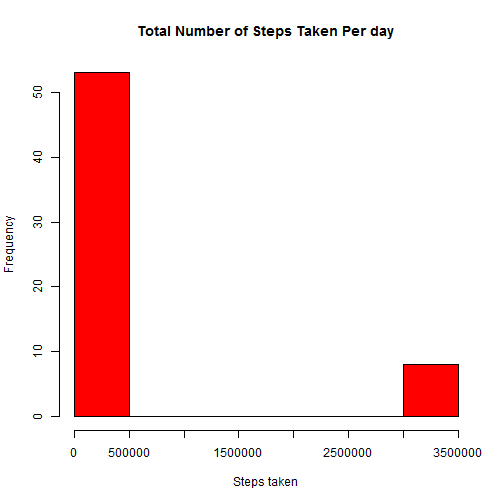

```r
h2 <- hist(newaggregatedSum$x, breaks = 10, col = "red", xlab = "Steps taken",
    main = "Total Number of Steps Taken Per day")
```